# Web Mining and Applied NLP (44-620)

## Final Project: Article Summarizer

### Student Name: Zach Fuller

Perform the tasks described in the Markdown cells below. When you have completed the assignment make sure your code cells have all been run (and have output beneath them) and ensure you have committed and pushed ALL of your changes to your assignment repository.

You should bring in code from previous assignments to help you answer the questions below.

Every question that requires you to write code will have a code cell underneath it; you may either write your entire solution in that cell or write it in a python file (`.py`), then import and run the appropriate code to answer the question.

## GitHub Repo: https://github.com/HundredDucks/44620_Module7

## Question 1

1. Find on the internet an article or blog post about a topic that interests you and you are able to get the text for using the technologies we have applied in the course. Get the html for the article and store it in a file (which you must submit with your project)

```python
#import modules needed for this assignment first
import requests
from bs4 import BeautifulSoup
import pickle
import spacy
from spacytextblob.spacytextblob import SpacyTextBlob
from collections import Counter
import numpy as np
import matplotlib as mpl
import matplotlib.pyplot as plt
```

```python
r = requests.get('https://www.npr.org/2022/11/18/1137819206/twitter-shutting-down-likelihood')

with open('twitter_article.pkl', 'wb') as f:
    pickle.dump(r.text, f)
```

```python
#also wrote to HTML for easier submission in Canvas, as it would not accept the pickle file above
with open('twitter_article.html', 'wb') as f:
    pickle.dump(r.text, f)
```

## Question 2

1. Read in your article's html source from the file you created in question 1 and do sentiment analysis on the article/post's text (use `.get_text()`). Print the polarity score with an appropriate label. Additionally print the number of sentences in the original article (with an appropriate label)

```python
with open('twitter_article.pkl', 'rb') as f:
    article_html = pickle.load(f)
```

```python
soup = BeautifulSoup(article_html, 'html5lib')
```

```python
#searching for the id of "storytext" elimnated some of the extra content in the article that I didn't want at least
#Is it possible to remove all of the lines of white space and the images and image text?
article_content = soup.find(id="storytext")
```

```python
print(article_content.get_text())
```

```
            Enlarge this image






                The departures of thousands of Twitter workers is raising fears about the stability of the influential social media site under new owner Elon Musk.


                    NurPhoto/NurPhoto via Getty Images


                hide caption




            toggle caption




        NurPhoto/NurPhoto via Getty Images














        The departures of thousands of Twitter workers is raising fears about the stability of the influential social media site under new owner Elon Musk.

```

[output cut: 38 more lines]

```








   Plus, there are safety and security concerns. Twitter saw a surge in racist and antisemitic tweets following Musk's takeover. Many of the staff and contractors who were laid off or resigned worked on teams curbing toxic and illegal content.   Musk framed his interest in buying Twitter in the firs…





   Musk's habit of abruptly announcing changes and features, and just as quickly reversing them, has left staff feeling whiplashed — and in some cases, redundant.   "A Twitter whose policies are defined by unilateral edict has little need for a trust and safety function dedicated to its principled d…
```

```python
nlp = spacy.load('en_core_web_sm')
nlp.add_pipe('spacytextblob')
```

```
<spacytextblob.spacytextblob.SpacyTextBlob at 0x2906f4d0bb0>
```

```python
doc = nlp(article_content.get_text())
print("Sentiment Analysis:", doc._.blob.sentiment_assessments.assessments)
```

```
Sentiment Analysis: [(['social'], 0.03333333333333333, 0.06666666666666667, None), (['new'], 0.13636363636363635, 0.45454545454545453, None), (['social'], 0.03333333333333333, 0.06666666666666667, None), (['new'], 0.13636363636363635, 0.45454545454545453, None), (['last'], 0.0, 0.06666666666666667, …
```

### Polarity Score

```python
print("Polarity Score:", doc._.blob.polarity)
```

```
Polarity Score: 0.004210214388785822
```

### Number of Sentences

```python
#wasn't quite sure the best way to do this, so had to do some Googling. Came upon something similar to this, seemed to work well.
sentence_tokens = [[token.text for token in sent] for sent in doc.sents]
print("Number of Sentences:", len(sentence_tokens))
```

```
Number of Sentences: 45
```

## Question 3

1. Load the article text into a trained `spaCy` pipeline, and determine the 5 most frequent tokens (converted to lower case). Print the common tokens with an appropriate label. Additionally, print the tokens their frequencies (with appropriate labels)

```python
def we_care_about(token):
    return not (token.is_space or token.is_punct or token.is_stop)
```

```python
interesting_tokens = [token for token in doc if we_care_about(token)]
word_freq = Counter(map(str,interesting_tokens))
print("The 5 most common tokens are " + str(word_freq.most_common(5)).lower())
```

```
The 5 most common tokens are [('twitter', 20), ('musk', 11), ('nurphoto', 6), ('platform', 5), ('employees', 5)]
```

## Question 4

1. Load the article text into a trained `spaCy` pipeline, and determine the 5 most frequent lemmas (converted to lower case). Print the common lemmas with an appropriate label. Additionally, print the lemmas with their frequencies (with appropriate labels).

```python
interesting_lemmas = [token.lemma_.lower() for token in doc if we_care_about(token)]
lemma_freq = Counter(interesting_lemmas)
print("The 5 most common lemmas and their counts are " + str(lemma_freq.most_common(5)))
```

```
The 5 most common lemmas and their counts are [('twitter', 20), ('musk', 11), ('employee', 10), ('nurphoto', 6), ('say', 6)]
```

## Question 5

1. Make a list containing the scores (using tokens) of every sentence in the article, and plot a histogram with appropriate titles and axis labels of the scores. From your histogram, what seems to be the most common range of scores (put the answer in a comment after your code)?

```python
frequent_tokens = set()
for token, freq in word_freq.most_common(5):
    frequent_tokens.add(token)
print(frequent_tokens)
```

```
{'Musk', 'employees', 'NurPhoto', 'platform', 'Twitter'}
```

```python
def token_list(sentence, interesting_token):
    sentences = list(sentence.sents)
    scores = list()
    for sentence in sentences:
        word_count_t = 0
        count_t = 0
        for word in sentence:
            if not(word.is_space or word.is_punct):
                word_count_t += 1
        for token in sentence:
            if token.lemma_.lower() in frequent_tokens:
                count_t += 1
        if count_t != 0:
            token_score = count_t/word_count_t
        else:
            token_score = 0
        scores.append(token_score)
    return scores
```

```python
tokens_data = token_list(doc, frequent_tokens)
```

```
[Text(0.5, 0, 'Score'),
```

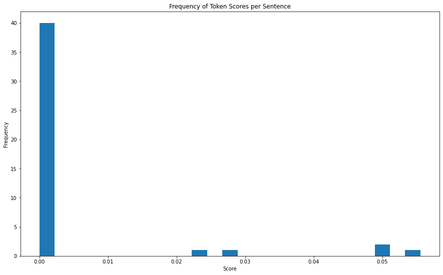

```python
fig, ax = plt.subplots(figsize=(15, 9))
ax.hist(tokens_data, bins=25)
ax.set(xlabel='Score', ylabel='Frequency', title='Frequency of Token Scores per Sentence')
```

```python
#The most common token score range seems to be about 0 - 0.0025
```

## Question 6

1. Make a list containing the scores (using lemmas) of every sentence in the article, and plot a histogram with appropriate titles and axis labels of the scores. From your histogram, what seems to be the most common range of scores (put the answer in a comment after your code)?

```python
frequent_lemmas = set()
for lemma, freq in lemma_freq.most_common(5):
    frequent_lemmas.add(lemma)
print(frequent_lemmas)
```

```
{'say', 'musk', 'employee', 'twitter', 'nurphoto'}
```

```python
def lemma_list(sentence, interesting_lemmas):
    sentences = list(sentence.sents)
    scores = list()
    for sentence in sentences:
        word_count_l = 0
        count_l = 0
        for word in sentence:
            if not(word.is_space or word.is_punct):
                word_count_l += 1
        for lemma in sentence:
            if lemma.lemma_.lower() in frequent_lemmas:
                count_l += 1
        if count_l != 0:
            lemma_score = count_l/word_count_l
        else:
            lemma_score = 0
        scores.append(lemma_score)
    return scores
```

```python
lemmas_data = lemma_list(doc, frequent_lemmas)
```

```
[Text(0.5, 0, 'Score'),
```

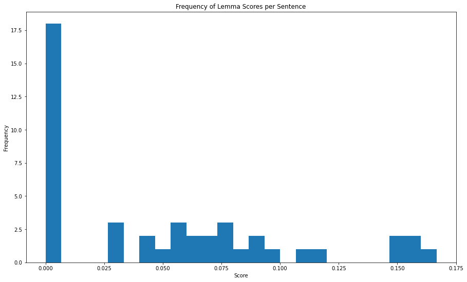

```python
fig, ax = plt.subplots(figsize=(15, 9))
ax.hist(lemmas_data, bins=25)
ax.set(xlabel='Score', ylabel='Frequency', title='Frequency of Lemma Scores per Sentence')
```

```python
#The most common score range seems to be about 0 - 0.005
```

## Question 7

1. Using the histograms from questions 5 and 6, decide a "cutoff" score for tokens and lemmas such that fewer than half the sentences would have a score greater than the cutoff score. Record the scores in this Markdown cell
- Cutoff Score (tokens): 0.0025
- Cutoff Score (lemmas): I initially thought it would be around 0.005, but after working on question 10, I found 0.1 to be more suitable to give me an appropriate sentence count

Feel free to change these scores as you generate your summaries. Ideally, we're shooting for at least 6 sentences for our summary, but don't want more than 10 (these numbers are rough estimates; they depend on the length of your article).

## Question 8

1. Create a summary of the article by going through every sentence in the article and adding it to an (initially) empty list if its score (based on tokens) is greater than the cutoff score you identified in question 8. If your loop variable is named `sent`, you may find it easier to add `sent.text.strip()` to your list of sentences. Print the summary (I would cleanly generate the summary text by `join`ing the strings in your list together with a space (`' '.join(sentence_list)`).

```python
def token_score_list(sentence, interesting_token):
    sentences = list(sentence.sents)
    scores = list()
    sentence_list = list()
    for sentence in sentences:
        word_count_t = 0
        count_t = 0
        for word in sentence:
            if not(word.is_space or word.is_punct):
                word_count_t += 1
        for token in sentence:
            if token.lemma_.lower() in frequent_tokens:
                count_t += 1
        if count_t != 0:
            token_score = count_t/word_count_t
        else:
            token_score = 0
        if token_score > 0.0025:
            sentence_list.append(sentence)
    return sentence_list
```

```python
token_score_list(doc, frequent_tokens)
```

```
[NurPhoto/NurPhoto via Getty Images





    People are singing their last birdsongs on Twitter, as some brace for what they fear will be a final farewell to the platform whose workforce has shrunk dramatically in the few weeks it's been owned by billionaire Elon Musk.   ,
 Untangling Disinformation
             Twitter employees quit in droves after Elon Musk's ultimatum passes









    Plus, there are concerns about the platform's capacity to handle traffic during big events, such as the World Cup kicking off this weekend.   ,
 While the platform is still functioning, many warn features may deteriorate as the site is run by a threadbare team.   ,
 With security, engineering and content moderation teams gutted, the platform is also more vulnerable to hacks and abuse.   ,
 Twitter is a platform that is "so complicated that truly nobody understands how it all works," another former employee said.]
```

## Question 9

1. Print the polarity score of your summary you generated with the token scores (with an appropriate label). Additionally, print the number of sentences in the summarized article.

```python
token_summary = str(token_score_list(doc, frequent_tokens))
```

```python
doc_token = nlp(token_summary)
print("Sentiment Analysis:", doc_token._.blob.sentiment_assessments.assessments)
```

```
Sentiment Analysis: [(['last'], 0.0, 0.06666666666666667, None), (['final'], 0.0, 1.0, None), (['few'], -0.2, 0.1, None), (['big'], 0.0, 0.1, None), (['such'], 0.0, 0.5, None), (['many'], 0.5, 0.5, None), (['more'], 0.5, 0.5, None), (['vulnerable'], -0.5, 0.5, None), (['complicated'], -0.5, 1.0, Non…
```

### Polarity Score

```python
print("Polarity Score:", doc_token._.blob.polarity)
```

```
Polarity Score: -0.019999999999999997
```

### Number of Sentences

```python
sentence_token_summary = [[token.text for token in sent] for sent in doc_token.sents]
print("Number of Sentences:", len(sentence_token_summary))
```

```
Number of Sentences: 7
```

## Question 10

1. Create a summary of the article by going through every sentence in the article and adding it to an (initially) empty list if its score (based on lemmas) is greater than the cutoff score you identified in question 8. If your loop variable is named `sent`, you may find it easier to add `sent.text.strip()` to your list of sentences. Print the summary (I would cleanly generate the summary text by `join`ing the strings in your list together with a space (`' '.join(sentence_list)`).

```python
def lemma_score_list(sentence, interesting_lemmas):
    sentences = list(sentence.sents)
    scores = list()
    sentence_l_list = list()
    for sentence in sentences:
        word_count_l = 0
        count_l = 0
        for word in sentence:
            if not(word.is_space or word.is_punct):
                word_count_l += 1
        for lemma in sentence:
            if lemma.lemma_.lower() in frequent_lemmas:
                count_l += 1
        if count_l != 0:
            lemma_score = count_l/word_count_l
        else:
            lemma_score = 0
        if lemma_score > 0.1:
            sentence_l_list.append(sentence)
    return sentence_l_list
```

```python
lemma_score_list(doc, frequent_lemmas)
```

```
[NurPhoto/NurPhoto via Getty Images


                 hide caption




             toggle caption




         NurPhoto/NurPhoto via Getty Images














         The departures of thousands of Twitter workers is raising fears about the stability of the influential social media site under new owner Elon Musk.


             ,
 Some former employees who chose not to sign onto Musk's new vision took to Twitter to explain their decisions.   ,
 Nothing more than what anyone can see on Twitter.,
 Yet the load that creates on Twitter's systems could become a tipping point, the former employee said.   ,
 Twitter saw a surge in racist and antisemitic tweets following Musk's takeover.,
 Musk framed his interest in buying Twitter in the first place as being about increasing free speech.,
 Twitter is a platform that is "so complicated that truly nobody understands how it all works," another former employee said.]
```

## Question 11

1. Print the polarity score of your summary you generated with the lemma scores (with an appropriate label). Additionally, print the number of sentences in the summarized article.

```python
lemma_summary = str(lemma_score_list(doc, frequent_lemmas))
```

```python
doc_lemma = nlp(lemma_summary)
print("Sentiment Analysis:", doc_lemma._.blob.sentiment_assessments.assessments)
```

```
Sentiment Analysis: [(['social'], 0.03333333333333333, 0.06666666666666667, None), (['new'], 0.13636363636363635, 0.45454545454545453, None), (['former'], 0.0, 0.0, None), (['new'], 0.13636363636363635, 0.45454545454545453, None), (['more'], 0.5, 0.5, None), (['former'], 0.0, 0.0, None), (['followin…
```

### Polarity Score

```python
print("Polarity Score:", doc_lemma._.blob.polarity)
```

```
Polarity Score: 0.08691460055096419
```

### Number of Sentences

```python
sentence_lemma_summary = [[lemma.text for lemma in sent] for sent in doc_lemma.sents]
print("Number of Sentences:", len(sentence_lemma_summary))
```

```
Number of Sentences: 6
```

## Question 12

1. Compare your polarity scores of your summaries to the polarity scores of the initial article. Is there a difference? Why do you think that may or may not be?. Answer in this Markdown cell.  
   The Polarity Score of the original article is 0.004210214388785822. The Polarity Score of the token summary is -0.019999999999999997. The Polarity Score of the lemma summary is 0.08691460055096419. All of these scores are very close to neutral. However, the key difference is that the original article and the lemma summary had very low but still positive scores, while the toekn summary had a very low but negative score. Since the summaries were based on filtering out sentences containing the most frequent tokens and lemmas, there were less sentences to analyze, meaning that the sentiment/polarity can easily be swayed positively or negatively, as the score of each individual word can have more weight when there are fewer total words in the article. Additionally, this article is about a currently hot topic, meaning that the key tokens/lemmas (Twitter, Elon, etc.) are likely to be included in somewhat sensationalized sentences. I think that this can sway the scores to be more negative. Adjusting the cutoff scores I derived from the plots in questions 5 and 6 would likely have a large impact on these scores, as allowing more sentences into the summaries could allow the results to be swayed further. I find it interesting that the frequent lemmas are more likely to pick up unimportant words like "say", while the frequent tokens are more likely to contain proper nouns and other words that have some emotion or opinion behind them.

## Question 13

1. Based on your reading of the original article, which summary do you think is better (if there's a difference). Why do you think this might be?